# WEBSITE CLASSIFICATION

To build a web classification model, we used the DMOZ dataset, a large communally maintained open directory that categorizes web content. DMOZ closed in 2017, because AOL no longer wished to support the project. We found the split version of the dataset in a Github repository.

The dataset contains 10 columns, which are: **-** id **-** url **-** title **-** description **-** priority **-** topic **-** topicId **-** stemd **-** topTerms **-** topStems

**Dataset:** https://github.com/ALSAREM/dmozNeo4j

## Combine CSV Files

```python
import os
import glob
import pandas as pd
```

```python
cwd = os.getcwd()
extension = 'csv'
all_filenames = [i for i in glob.glob('*.{}'.format(extension))]
combined_csv = pd.concat([pd.read_csv(f, nrows=500) for f in all_filenames])
combined_csv.to_csv("combined_csv_small_data.csv", index=False, encoding='utf-8-sig')
```

## Import Libraries

```python
!pip install wordcloud
!pip install nltk
!pip install spacy
```

```python
import re
import nltk
import ssl
import numpy as np
import spacy as sp
import pandas as pd
import seaborn as sns
import matplotlib.pyplot as plt
from wordcloud import WordCloud
from collections import Counter
from sklearn.pipeline import FeatureUnion
from sklearn.naive_bayes import MultinomialNB
from sklearn.tree import DecisionTreeClassifier
from sklearn.linear_model import LogisticRegression
from sklearn.ensemble import RandomForestClassifier
from sklearn.model_selection import cross_val_predict, GroupKFold, train_test_split
from sklearn.feature_extraction.text import CountVectorizer, TfidfVectorizer
from sklearn.metrics import f1_score, confusion_matrix, accuracy_score, classification_report
sp.prefer_gpu()
nlp = sp.load("en_core_web_sm")

try:
    _create_unverified_https_context = ssl._create_unverified_context
except AttributeError:
    pass
else:
    ssl._create_default_https_context = _create_unverified_https_context

nltk.download('stopwords')
```

```
True
```

## Import Data

Import the CSV file

```python
websites = pd.read_csv(r'combined_csv_small_data.csv')
websites
```

|  | id | url | title | description | priority | topic | topicid | stemd | topTerms | topStems |
| --- | --- | --- | --- | --- | --- | --- | --- | --- | --- | --- |
| 0 | http://www.firstworldwar.com/bio/lloydgeorge.htm | http://www.firstworldwar.com/bio/lloydgeorge.htm | First World War.org - David Lloyd George | Short Biography from a site devoted to The Gre... | -1 | Top/Regional/Europe/United_Kingdom/Society_and... | top_regional_europe_united_kingdom_society_and... | top region europ unit kingdom societi and cult... | NaN | NaN |
| 1 | http://www.llgc.org.uk/ardd/dlgeorge/dlg0002.htm | http://www.llgc.org.uk/ardd/dlgeorge/dlg0002.htm | David Lloyd George Exhibition 1863-1945 (March... | Online exhibition about the life of David Lloy... | -1 | Top/Regional/Europe/United_Kingdom/Society_and... | top_regional_europe_united_kingdom_society_and... | top region europ unit kingdom societi and cult... | lloyd, george, | david lloyd george, |
| 2 | http://www.infobritain.co.uk/David_Lloyd_Georg... | http://www.infobritain.co.uk/David_Lloyd_Georg... | InfoBritain: David Lloyd George | Biographical article with a portrait. | -1 | Top/Regional/Europe/United_Kingdom/Society_and... | top_regional_europe_united_kingdom_society_and... | top region europ unit kingdom societi and cult... | NaN | NaN |
| 3 | http://spartacus-educational.com/PRgeorge.htm | http://spartacus-educational.com/PRgeorge.htm | Lloyd George, David | Short biography by Spartacus Educational. | -1 | Top/Regional/Europe/United_Kingdom/Society_and... | top_regional_europe_united_kingdom_society_and... | top region europ unit kingdom societi and cult... | NaN | NaN |
| 4 | http://www.liberalhistory.org.uk/history/lloyd... | http://www.liberalhistory.org.uk/history/lloyd... | Liberal Democrat History Group: Lloyd-George, ... | Article written by Chris Wrigley. | -1 | Top/Regional/Europe/United_Kingdom/Society_and... | top_regional_europe_united_kingdom_society_and... | top region europ unit kingdom societi and cult... | NaN | lloyd george, |
| ... | ... | ... | ... | ... | ... | ... | ... | ... | ... | ... |
| 19495 | http://needlesearch.mozdev.org/ | http://needlesearch.mozdev.org/ | NeedleSearch | Lets you bookmark search engines for future us... | -1 | Top/Computers/Software/Internet/Clients/SeaMon... | top_computers_software_internet_clients_seamon... | top comput softwar internet client seamonkey a... | NaN | search, |
| 19496 | http://nextimage.mozdev.org/ | http://nextimage.mozdev.org/ | mozdev.org - nextimage: index | An extension for Mozilla that can detect an im... | -1 | Top/Computers/Software/Internet/Clients/SeaMon... | top_computers_software_internet_clients_seamon... | top comput softwar internet client seamonkey a... | NaN | NaN |
| 19497 | http://pubmed.mozdev.org/ | http://pubmed.mozdev.org/ | PubMed | Allows you to search for information in NLM Me... | -1 | Top/Computers/Software/Internet/Clients/SeaMon... | top_computers_software_internet_clients_seamon... | top comput softwar internet client seamonkey a... | NaN | NaN |
| 19498 | http://slashzilla.mozdev.org/ | http://slashzilla.mozdev.org/ | Slashzilla | A sidebar panel that provides the user with an... | -1 | Top/Computers/Software/Internet/Clients/SeaMon... | top_computers_software_internet_clients_seamon... | top comput softwar internet client seamonkey a... | NaN | NaN |
| 19499 | http://stormzilla.mozdev.org/ | http://stormzilla.mozdev.org/ | StormZilla | An extension to view your weather report via y... | -1 | Top/Computers/Software/Internet/Clients/SeaMon... | top_computers_software_internet_clients_seamon... | top comput softwar internet client seamonkey a... | NaN | NaN |

19500 rows × 10 columns

Our small dataset contains 19500 rows.

```python
websites.shape
```

```
(19500, 10)
```

```python
print(websites.columns)
```

```
Index(['id', 'url', 'title', 'description', 'priority', 'topic', 'topicid',
       'stemd', 'topTerms', 'topStems'],
      dtype='object')
```

## Data Exploration & Preprocessing

We delete unnecessary columns other than url, title, description, topic. The id column was the same with url so we dropped that one too.

```python
del websites['id']
del websites['priority']
del websites['topicid']
del websites['stemd']
del websites['topTerms']
del websites['topStems']
```

```python
websites.head()
```

|  | url | title | description | topic |
| --- | --- | --- | --- | --- |
| 0 | http://www.firstworldwar.com/bio/lloydgeorge.htm | First World War.org - David Lloyd George | Short Biography from a site devoted to The Gre... | Top/Regional/Europe/United_Kingdom/Society_and... |
| 1 | http://www.llgc.org.uk/ardd/dlgeorge/dlg0002.htm | David Lloyd George Exhibition 1863-1945 (March... | Online exhibition about the life of David Lloy... | Top/Regional/Europe/United_Kingdom/Society_and... |
| 2 | http://www.infobritain.co.uk/David_Lloyd_Georg... | InfoBritain: David Lloyd George | Biographical article with a portrait. | Top/Regional/Europe/United_Kingdom/Society_and... |
| 3 | http://spartacus-educational.com/PRgeorge.htm | Lloyd George, David | Short biography by Spartacus Educational. | Top/Regional/Europe/United_Kingdom/Society_and... |
| 4 | http://www.liberalhistory.org.uk/history/lloyd... | Liberal Democrat History Group: Lloyd-George, ... | Article written by Chris Wrigley. | Top/Regional/Europe/United_Kingdom/Society_and... |

Check if there are any null values in url column.

```python
websites['url'].isnull().sum()
```

```
0
```

```python
websites.info()
```

```
<class 'pandas.core.frame.DataFrame'>
RangeIndex: 19500 entries, 0 to 19499
Data columns (total 4 columns):
 #   Column       Non-Null Count  Dtype
---  ------       --------------  -----
 0   url          19500 non-null  object
 1   title        19500 non-null  object
 2   description  19498 non-null  object
 3   topic        19500 non-null  object
dtypes: object(4)
memory usage: 609.5+ KB
```

To get a category for each url, we had to split the topic column. We used a regular expression to get the second string which is between two slashes and we added this string to our data frame under a new column called 'category'.

```python
x = websites.topic[1]
print(x)
```

```
Top/Regional/Europe/United_Kingdom/Society_and_Culture/History/Parliament/Prime_Ministers/Lloyd_George,_David
```

```python
x = re.search('\/(.*?)\/', x).group(1)
print(x)
```

```
Regional
```

```python
websites['category'] = websites.topic.str.extract('\/(.*?)\/', expand = True)
```

```python
websites.head()
```

|  | url | title | description | topic | category |
| --- | --- | --- | --- | --- | --- |
| 0 | http://www.firstworldwar.com/bio/lloydgeorge.htm | First World War.org - David Lloyd George | Short Biography from a site devoted to The Gre... | Top/Regional/Europe/United_Kingdom/Society_and... | Regional |
| 1 | http://www.llgc.org.uk/ardd/dlgeorge/dlg0002.htm | David Lloyd George Exhibition 1863-1945 (March... | Online exhibition about the life of David Lloy... | Top/Regional/Europe/United_Kingdom/Society_and... | Regional |
| 2 | http://www.infobritain.co.uk/David_Lloyd_Georg... | InfoBritain: David Lloyd George | Biographical article with a portrait. | Top/Regional/Europe/United_Kingdom/Society_and... | Regional |
| 3 | http://spartacus-educational.com/PRgeorge.htm | Lloyd George, David | Short biography by Spartacus Educational. | Top/Regional/Europe/United_Kingdom/Society_and... | Regional |
| 4 | http://www.liberalhistory.org.uk/history/lloyd... | Liberal Democrat History Group: Lloyd-George, ... | Article written by Chris Wrigley. | Top/Regional/Europe/United_Kingdom/Society_and... | Regional |

To check if there are any duplicate url, we sort the data frame by url column.

```python
websites[websites.url.duplicated(keep=False)].sort_values(by='url')
```

|  | url | title | description | topic | category |
| --- | --- | --- | --- | --- | --- |
| 16902 | http://about-britain.com/institutions/compare-... | Brexit - The People and Arguments For and Against | Tabular presentation of the case put by both s... | Top/Regional/Europe/United_Kingdom/Society_and... | Regional |
| 402 | http://about-britain.com/institutions/compare-... | Brexit - The People and Arguments For and Against | Tabular presentation of the case put by both s... | Top/Regional/Europe/United_Kingdom/Society_and... | Regional |
| 19158 | http://archivemail.sourceforge.net/ | archivemail | Python tool for detecting and compressing olde... | Top/Computers/Software/Internet/Clients/Mail/Unix | Computers |
| 19186 | http://archivemail.sourceforge.net/ | Archivemail | Tool for archiving IMAP, mbox, MH and Maildir ... | Top/Computers/Software/Internet/Clients/Mail/U... | Computers |
| 458 | http://armbritain.com/forum/index.php | Britain - Campaign for Armed Self-Defence | Forum discussing gun issues including right to... | Top/Regional/Europe/United_Kingdom/Society_and... | Regional |
| ... | ... | ... | ... | ... | ... |
| 441 | https://www.whatdotheyknow.com/ | WhatDoTheyKnow? | Online free-access archive that allows users t... | Top/Regional/Europe/United_Kingdom/Society_and... | Regional |
| 16928 | https://www.youtube.com/watch?v=FdLcRme3jZE | YouTube: Brexit Secretary David Davis Statemen... | 105 minute video of presentation to the House ... | Top/Regional/Europe/United_Kingdom/Society_and... | Regional |
| 428 | https://www.youtube.com/watch?v=FdLcRme3jZE | YouTube: Brexit Secretary David Davis Statemen... | 105 minute video of presentation to the House ... | Top/Regional/Europe/United_Kingdom/Society_and... | Regional |
| 420 | https://www.youtube.com/watch?v=yIKyad2JOcc | YouTube: Brexit Minister David Davis vs Anti-B... | The first speech to the House of Commons since... | Top/Regional/Europe/United_Kingdom/Society_and... | Regional |
| 16920 | https://www.youtube.com/watch?v=yIKyad2JOcc | YouTube: Brexit Minister David Davis vs Anti-B... | The first speech to the House of Commons since... | Top/Regional/Europe/United_Kingdom/Society_and... | Regional |

1211 rows × 5 columns

As seen above, we have duplicate data. We will keep the last one of the duplicates and drop others.

```python
websites = websites.sort_values('url').drop_duplicates(subset=['url'], keep='last')
```

```python
websites[websites.url.duplicated(keep=False)].sort_values(by='url')
```

|  | url | title | description | topic | category |
| --- | --- | --- | --- | --- | --- |

Check if the category column contains any null values and drop them.

```python
websites['category'].isnull().sum()
```

```
0
```

```python
websites = websites[websites['category'].notna()]
```

```python
websites['category'].isnull().sum()
```

```
0
```

We have 10 categories in total.

```python
len(websites.category.unique())
```

```
10
```

```python
websites.category.unique()
```

```
array(['Computers', 'World', 'Regional', 'Society', 'Arts', 'Shopping',
       'Home', 'Business', 'Reference', 'Sports'], dtype=object)
```

We can visualize the number of urls for each category.

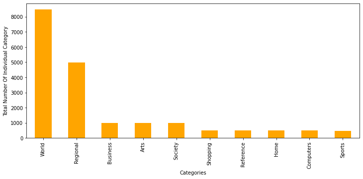

```python
websites.category.value_counts().plot(figsize=(12,5), kind='bar', color='orange');
plt.xlabel('Categories')
plt.ylabel('Total Number Of Individual Category')
```

We can also plot it whit Seaborn library.

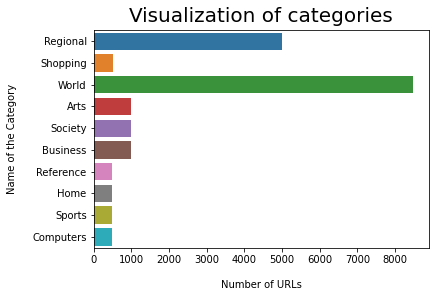

```python
ax = sns.countplot(y="category",  data=websites)
plt.title("Visualization of categories", y=1.01, fontsize=20)
plt.ylabel("Name of the Category", labelpad=15)
plt.xlabel("Number of URLs", labelpad=15)
```

```python
websites = websites[websites['description'].notna()]
```

The we sort the dataframe based on index value and add a column called 'id'. We also moved the id column to the front of the data frame.

```python
websites = websites.sort_index(axis = 0)
```

```python
websites["id"] = websites.index + 1
```

```python
first_column = websites.pop('id')
websites.insert(0, 'id', first_column)
```

```python
del websites['topic']
```

```python
websites.shape
```

```
(18888, 5)
```

```python
websites
```

|  | id | url | title | description | category |
| --- | --- | --- | --- | --- | --- |
| 0 | 1 | http://www.firstworldwar.com/bio/lloydgeorge.htm | First World War.org - David Lloyd George | Short Biography from a site devoted to The Gre... | Regional |
| 2 | 3 | http://www.infobritain.co.uk/David_Lloyd_Georg... | InfoBritain: David Lloyd George | Biographical article with a portrait. | Regional |
| 3 | 4 | http://spartacus-educational.com/PRgeorge.htm | Lloyd George, David | Short biography by Spartacus Educational. | Regional |
| 7 | 8 | http://pubs.socialistreviewindex.org.uk/sr203/... | Socialist Review: The man who turned his back ... | Dave Renton describes the life of Ramsay MacDo... | Regional |
| 8 | 9 | http://www.infobritain.co.uk/James_Ramsay_Macd... | InfoBritain: James Ramsay Macdonald | Biographical article. | Regional |
| ... | ... | ... | ... | ... | ... |
| 19495 | 19496 | http://needlesearch.mozdev.org/ | NeedleSearch | Lets you bookmark search engines for future us... | Computers |
| 19496 | 19497 | http://nextimage.mozdev.org/ | mozdev.org - nextimage: index | An extension for Mozilla that can detect an im... | Computers |
| 19497 | 19498 | http://pubmed.mozdev.org/ | PubMed | Allows you to search for information in NLM Me... | Computers |
| 19498 | 19499 | http://slashzilla.mozdev.org/ | Slashzilla | A sidebar panel that provides the user with an... | Computers |
| 19499 | 19500 | http://stormzilla.mozdev.org/ | StormZilla | An extension to view your weather report via y... | Computers |

18888 rows × 5 columns

# Part 1 - Ceren Çiçek

## Text Preprocessing & Visualization

spaCy is a library, which is designed for Natural Language Processing (NLP) to process and understand large volumes of text. We will use this library to clean our texts by removing pronouns, stopwords, and lowercasing all words.

We first tokenized the text, segmented it into words, and for each token, we check if it is a stopword (the, a, an, is...), punctuation, a numeric value, or a null value. If any of those situations is true, we do not add this word to our tokens array.

```python
def clean_text(doc):
    doc = nlp(doc)
    tokens = []
    exclusion_list = ["nan"]
    for token in doc:
        if token.is_stop or token.is_punct or token.text.isnumeric() or (token.text.isalnum()==False) or token.text in exclusion_list :
            continue
        token = str(token.lemma_.lower().strip())
        tokens.append(token)
    return " ".join(tokens)
```

```python
websites['title']= websites['title'].convert_dtypes()
```

```python
type(websites['title'])
```

```
pandas.core.series.Series
```

With clean_text function, we cleaned title columns from stopwords, punctuations and save them to our data frame with a new attribute 'cleaned_text'.

```python
websites["cleaned_text"]  = websites.apply(lambda row: clean_text(row["title"]) ,axis=1)
```

```python
websites
```

|  | id | url | title | description | category | cleaned_text |
| --- | --- | --- | --- | --- | --- | --- |
| 0 | 1 | http://www.firstworldwar.com/bio/lloydgeorge.htm | First World War.org - David Lloyd George | Short Biography from a site devoted to The Gre... | Regional | world david lloyd george |
| 2 | 3 | http://www.infobritain.co.uk/David_Lloyd_Georg... | InfoBritain: David Lloyd George | Biographical article with a portrait. | Regional | infobritain david lloyd george |
| 3 | 4 | http://spartacus-educational.com/PRgeorge.htm | Lloyd George, David | Short biography by Spartacus Educational. | Regional | lloyd george david |
| 7 | 8 | http://pubs.socialistreviewindex.org.uk/sr203/... | Socialist Review: The man who turned his back ... | Dave Renton describes the life of Ramsay MacDo... | Regional | socialist review man turn labour ramsay macdonald |
| 8 | 9 | http://www.infobritain.co.uk/James_Ramsay_Macd... | InfoBritain: James Ramsay Macdonald | Biographical article. | Regional | infobritain james ramsay macdonald |
| ... | ... | ... | ... | ... | ... | ... |
| 19495 | 19496 | http://needlesearch.mozdev.org/ | NeedleSearch | Lets you bookmark search engines for future us... | Computers | needlesearch |
| 19496 | 19497 | http://nextimage.mozdev.org/ | mozdev.org - nextimage: index | An extension for Mozilla that can detect an im... | Computers | nextimage index |
| 19497 | 19498 | http://pubmed.mozdev.org/ | PubMed | Allows you to search for information in NLM Me... | Computers | pubmed |
| 19498 | 19499 | http://slashzilla.mozdev.org/ | Slashzilla | A sidebar panel that provides the user with an... | Computers | slashzilla |
| 19499 | 19500 | http://stormzilla.mozdev.org/ | StormZilla | An extension to view your weather report via y... | Computers | stormzilla |

18888 rows × 6 columns

We can visualize the most frequent 20 words for each category.

```python
categories = websites["category"].unique()
```

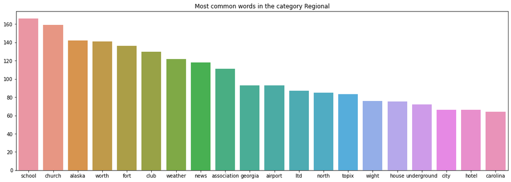

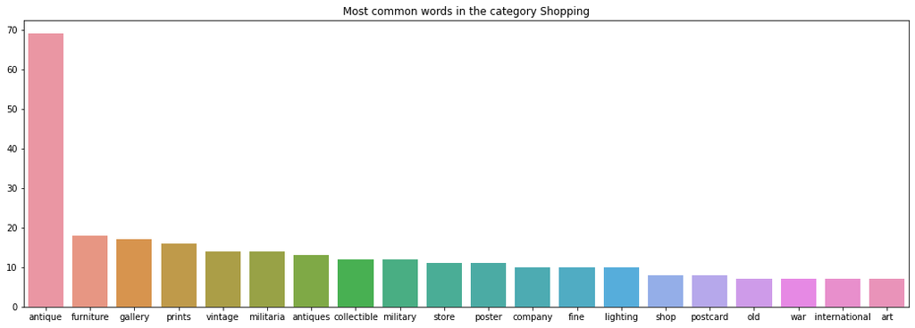

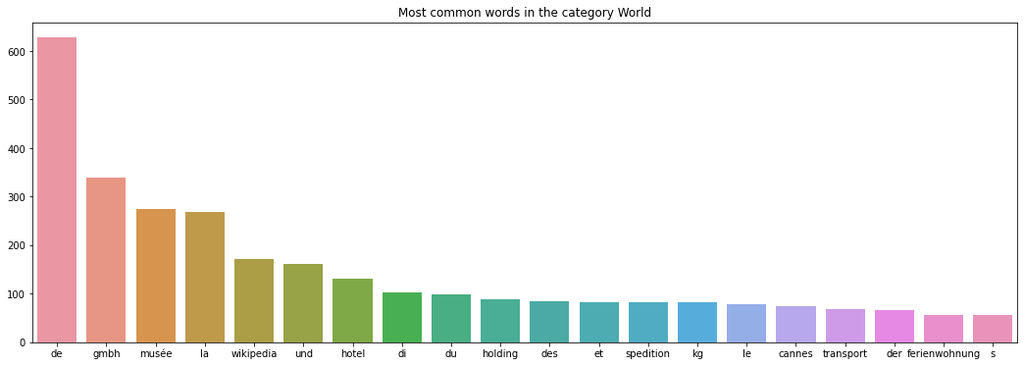

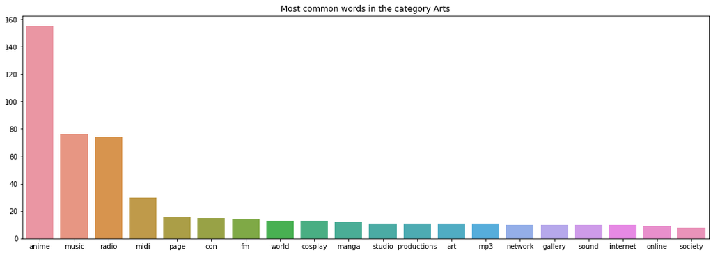

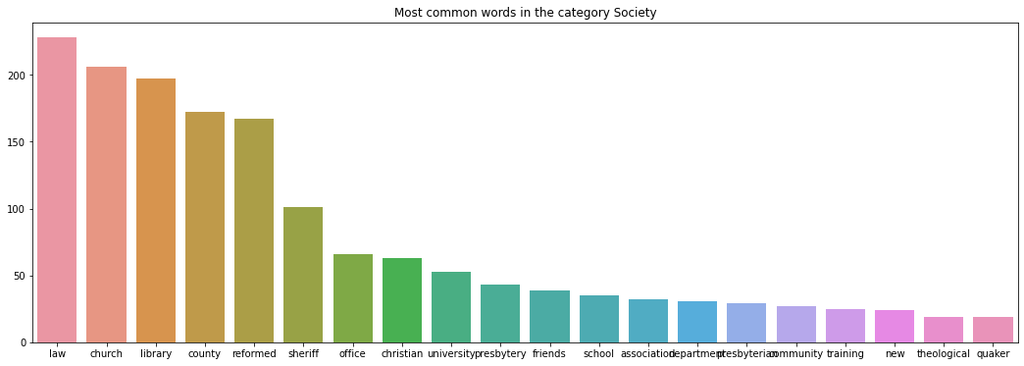

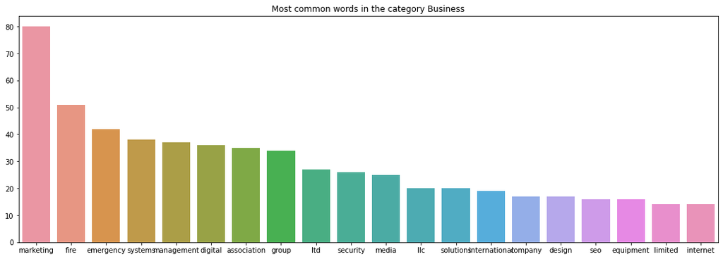

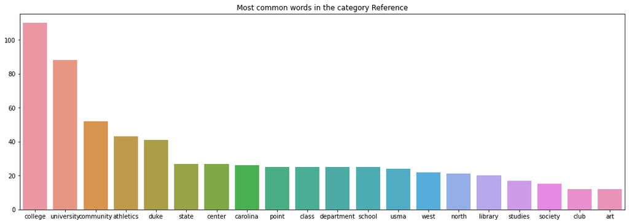

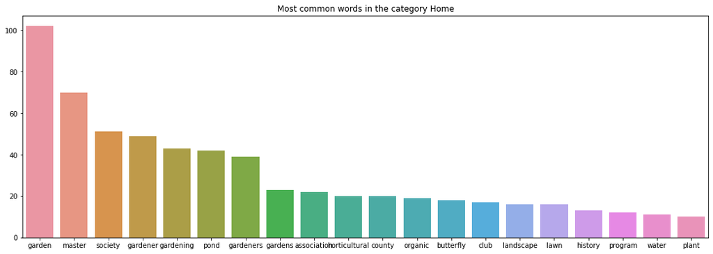

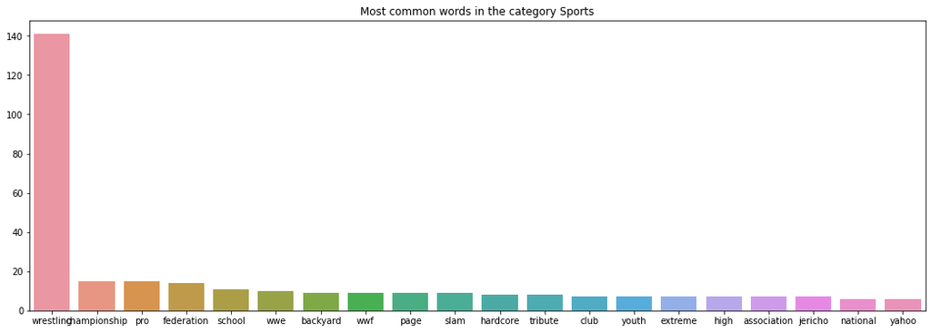

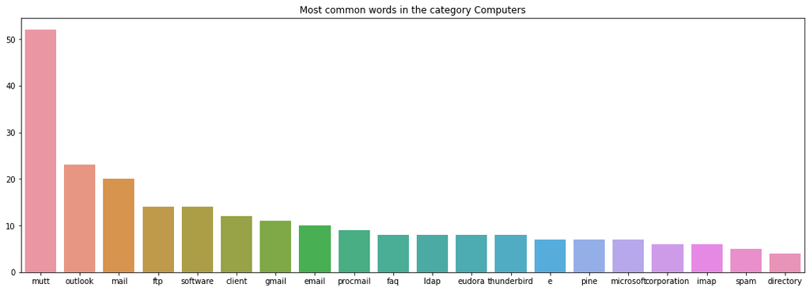

```python
for category in categories:
    c_category = websites[websites["category"] == category]
    texts = " ".join([row for row in c_category["cleaned_text"]])
    top_20_words = [word for word,count in Counter(texts.split()).most_common(20)]
    top_20_counts = [count for word,count in Counter(texts.split()).most_common(20)]
    fig = plt.figure(figsize=(18,6))
    sns.barplot(x=top_20_words, y=top_20_counts)
    plt.title("Most common words in the category "+ category)
    plt.show()
```

## Train & Test Data

We split 25% of the data for testing and the other for training.

We will classify the website based on the words that are included in the title of the webpage. We will predict the category.

```python
X = websites.cleaned_text
y = websites.category
X_train, X_test, y_train, y_test = train_test_split(X, y, test_size=0.25, random_state = 42)
```

Our train data contains 14166 websites and we have 4722 websites for testing.

```python
X_train.shape, y_train.shape, X_test.shape, y_test.shape
```

```
((14166,), (14166,), (4722,), (4722,))
```

TfidfVectorizer transforms text to feature vectors that can be used as input to the estimator. We will use it to calculate the weight of each word for each text document.

```python
tfidf_vectorizer = TfidfVectorizer(use_idf=True, min_df = 5, max_df=0.99, dtype='float32')
tfidf_vectorizer.fit_transform(websites["cleaned_text"])
```

```
<18888x1571 sparse matrix of type '<class 'numpy.float32'>'
	with 27894 stored elements in Compressed Sparse Row format>
```

```python
X_train = tfidf_vectorizer.transform(X_train)
X_test = tfidf_vectorizer.transform(X_test)
```

### 1) Logistic Regression Model

```python
logreg = LogisticRegression(class_weight=None, max_iter=100)
```

```python
logreg.fit(X_train, y_train)
```

```
LogisticRegression()
```

```python
y_prediction = logreg.predict(X_test)

print(classification_report(y_test, y_prediction, target_names=categories))
```

```
              precision    recall  f1-score   support

    Regional       0.93      0.43      0.59       262
    Shopping       0.73      0.38      0.50       263
       World       0.89      0.34      0.49       121
        Arts       0.94      0.71      0.81       115
     Society       0.81      0.48      0.60       128
    Business       0.77      0.72      0.75      1204
   Reference       0.87      0.39      0.54       124
        Home       0.92      0.73      0.81       237
      Sports       1.00      0.41      0.58       101
   Computers       0.74      0.97      0.84      2167

    accuracy                           0.77      4722
   macro avg       0.86      0.56      0.65      4722
weighted avg       0.79      0.77      0.75      4722
```

1) Precision is the ability of a classifier not to label an instance positive that is actually negative. In Sports category, precision value is 1.00 which means all of predictions were correct.

2) The recall is the ability of a classifier to find all positive instances. So it defines the percentage of the positive cases we had caught. The macro average (mean average) is 0.56 which shows us that we only caught about half of the positive cases.

3) The F1 score is a weighted harmonic mean of precision and recall such that the best score is 1.0 and the worst is 0.0.

4) Support is the number of actual occurrences of the class in the specified dataset. It seems that our support values are imbalanced, which may indicate weaknesses in the reported scores.

```python
logreg_acc = accuracy_score(y_prediction, y_test)
print('accuracy %s' % logreg_acc)
```

```
accuracy 0.7693773824650572
```

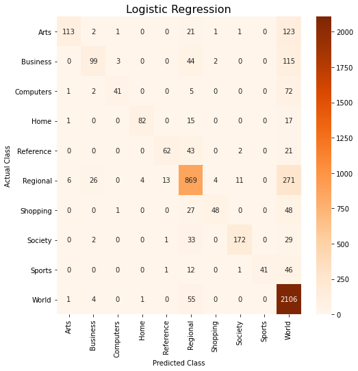

```python
cf_matrix = confusion_matrix(y_test, y_prediction)
fig, ax = plt.subplots(figsize=(8,8))
sns.heatmap(cf_matrix, annot=True, cmap="Oranges", fmt='d', xticklabels=logreg.classes_, yticklabels=logreg.classes_)
plt.ylabel('Actual Class')
plt.xlabel('Predicted Class')
plt.title("Logistic Regression", size=16);
```

The diagonal values show the number of correct predicted values. For instance, with this model, 2106 websites have been correctly classified as the 'World' category. But 55 websites have been classified as 'Regional while their correct category was 'World'.

The high number of incorrect predictions are:

- 123 websites with category Arts, predicted as World.
- 115 websites with category Business, predicted as World.
- 72 websites with category Computers, predicted as World.
- 271 websites with category Regional, predicted as World.

### 2) Decision Tree Model

```python
tree_model = DecisionTreeClassifier(min_samples_leaf=25, min_samples_split=25)
tree_model.fit(X_train, y_train)
```

```
DecisionTreeClassifier(min_samples_leaf=25, min_samples_split=25)
```

```python
y_prediction = tree_model.predict(X_test)

print(classification_report(y_test, y_prediction,target_names=categories))
```

```
              precision    recall  f1-score   support

    Regional       0.91      0.32      0.48       262
    Shopping       0.71      0.15      0.25       263
       World       1.00      0.13      0.23       121
        Arts       0.78      0.57      0.66       115
     Society       0.68      0.40      0.50       128
    Business       0.75      0.40      0.52      1204
   Reference       1.00      0.18      0.30       124
        Home       0.87      0.63      0.73       237
      Sports       1.00      0.30      0.46       101
   Computers       0.60      0.98      0.75      2167

    accuracy                           0.65      4722
   macro avg       0.83      0.41      0.49      4722
weighted avg       0.71      0.65      0.61      4722
```

```python
tree_acc = accuracy_score(y_prediction, y_test)
print('accuracy %s' % tree_acc)
```

```
accuracy 0.650571791613723
```

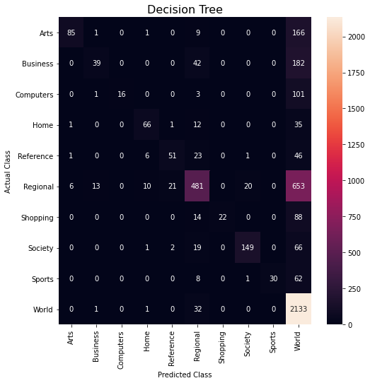

```python
cf_matrix = confusion_matrix(y_test, y_prediction)
fig, ax = plt.subplots(figsize=(8,8))
sns.heatmap(cf_matrix, annot=True, fmt='d', xticklabels=tree_model.classes_, yticklabels=tree_model.classes_)
plt.ylabel('Actual Class')
plt.xlabel('Predicted Class')
plt.title("Decision Tree", size=16);
```

### 3) Multinomial Naive Bayes

```python
multiNB_model = MultinomialNB(alpha=.01)
multiNB_model.fit(X_train, y_train)
```

```
MultinomialNB(alpha=0.01)
```

```python
y_prediction = multiNB_model.predict(X_test)
print(classification_report(y_test, y_prediction, target_names=categories))
```

```
              precision    recall  f1-score   support

    Regional       0.78      0.47      0.59       262
    Shopping       0.68      0.43      0.53       263
       World       0.73      0.38      0.50       121
        Arts       0.87      0.65      0.75       115
     Society       0.77      0.54      0.63       128
    Business       0.76      0.73      0.75      1204
   Reference       0.68      0.41      0.51       124
        Home       0.88      0.77      0.82       237
      Sports       0.70      0.40      0.51       101
   Computers       0.78      0.96      0.86      2167

    accuracy                           0.78      4722
   macro avg       0.76      0.58      0.65      4722
weighted avg       0.77      0.78      0.76      4722
```

```python
multiNB_acc = accuracy_score(y_prediction, y_test)
print('accuracy %s' % multiNB_acc)
```

```
accuracy 0.777424819991529
```

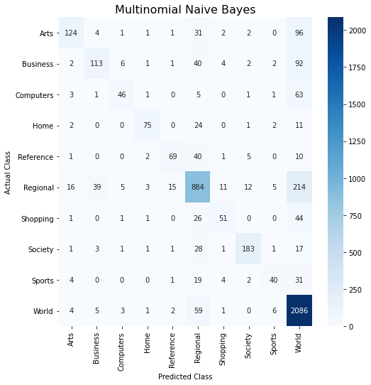

```python
cf_matrix = confusion_matrix(y_test, y_prediction)
fig, ax = plt.subplots(figsize=(8,8))
sns.heatmap(cf_matrix, annot=True, cmap="Blues", fmt='d', xticklabels=multiNB_model.classes_, yticklabels=multiNB_model.classes_)
plt.ylabel('Actual Class')
plt.xlabel('Predicted Class')
plt.title("Multinomial Naive Bayes", size=16);
```

When we compared the 3 models, we see that they have close averages of precision, recall, and f1-score values but the decision tree model seems to have a poor performance.

```python
print("Accuracy of Logistic Regression: ", logreg_acc)
print("Accuracy of Decision Tree: ", tree_acc)
print("Accuracy of Multinomial Naive Bayes: ", multiNB_acc)
```

[output not shown]

# Part 2 - Gizem Kurnaz

## Text Preprocessing with NLTK

We removed special characters and numbers, convert document to lowercase, tokenized documents, filtered out the stop-words, reconstructed the document, using some methods in this package.Then we added those cleaned title texts under a new column 'cleane_title'.

```python
WPT = nltk.WordPunctTokenizer()
stop_word_list = nltk.corpus.stopwords.words('english')

def norm_doc(single_doc):
    # EN: Remove special characters and numbers
    single_doc = re.sub(r'\d+', '', single_doc)
    pattern = r"[{}]".format(",.;_:!’")
    single_doc = re.sub(pattern, " ", single_doc)
    # EN: Convert document to lowercase
    single_doc = single_doc.lower()
    single_doc = single_doc.strip()
    # EN: Tokenize documents
    tokens = WPT.tokenize(single_doc)
    # EN: Filter out the stop-words
    filtered_tokens = [token for token in tokens if token not in stop_word_list]
    # EN: Reconstruct the document
    single_doc = ' '.join(filtered_tokens)
    return single_doc

norm_docs = np.vectorize(norm_doc)
```

```python
websites['clean_title'] = norm_docs(websites.title)
```

```python
websites
```

|  | id | url | title | description | category | cleaned_text | clean_title |
| --- | --- | --- | --- | --- | --- | --- | --- |
| 0 | 1 | http://www.firstworldwar.com/bio/lloydgeorge.htm | First World War.org - David Lloyd George | Short Biography from a site devoted to The Gre... | Regional | world david lloyd george | first world war org - david lloyd george |
| 2 | 3 | http://www.infobritain.co.uk/David_Lloyd_Georg... | InfoBritain: David Lloyd George | Biographical article with a portrait. | Regional | infobritain david lloyd george | infobritain david lloyd george |
| 3 | 4 | http://spartacus-educational.com/PRgeorge.htm | Lloyd George, David | Short biography by Spartacus Educational. | Regional | lloyd george david | lloyd george david |
| 7 | 8 | http://pubs.socialistreviewindex.org.uk/sr203/... | Socialist Review: The man who turned his back ... | Dave Renton describes the life of Ramsay MacDo... | Regional | socialist review man turn labour ramsay macdonald | socialist review man turned back labour - rams... |
| 8 | 9 | http://www.infobritain.co.uk/James_Ramsay_Macd... | InfoBritain: James Ramsay Macdonald | Biographical article. | Regional | infobritain james ramsay macdonald | infobritain james ramsay macdonald |
| ... | ... | ... | ... | ... | ... | ... | ... |
| 19495 | 19496 | http://needlesearch.mozdev.org/ | NeedleSearch | Lets you bookmark search engines for future us... | Computers | needlesearch | needlesearch |
| 19496 | 19497 | http://nextimage.mozdev.org/ | mozdev.org - nextimage: index | An extension for Mozilla that can detect an im... | Computers | nextimage index | mozdev org - nextimage index |
| 19497 | 19498 | http://pubmed.mozdev.org/ | PubMed | Allows you to search for information in NLM Me... | Computers | pubmed | pubmed |
| 19498 | 19499 | http://slashzilla.mozdev.org/ | Slashzilla | A sidebar panel that provides the user with an... | Computers | slashzilla | slashzilla |
| 19499 | 19500 | http://stormzilla.mozdev.org/ | StormZilla | An extension to view your weather report via y... | Computers | stormzilla | stormzilla |

18888 rows × 7 columns

## Visualization with Wordcloud

We used wordcloud to find the most frequently occuring words so we saw in which labels, what type of websites are frequently occuring.

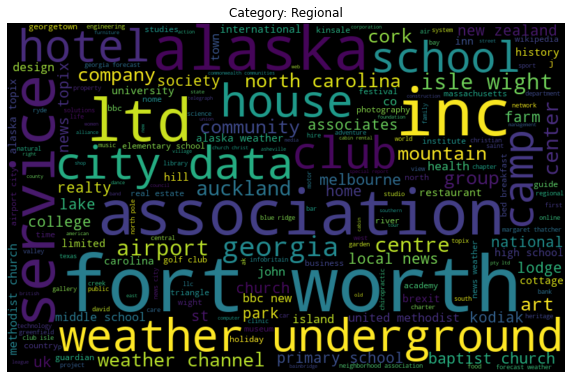

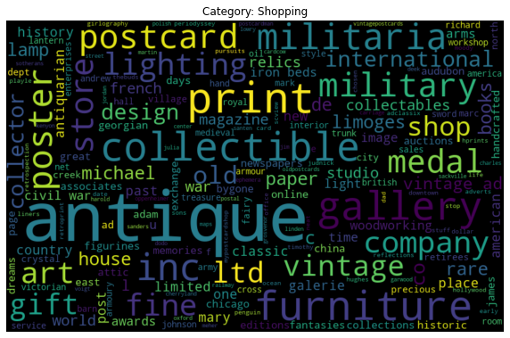

[figure not shown]

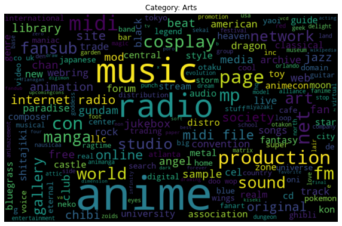

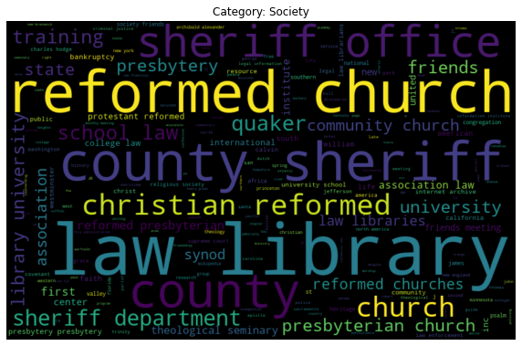

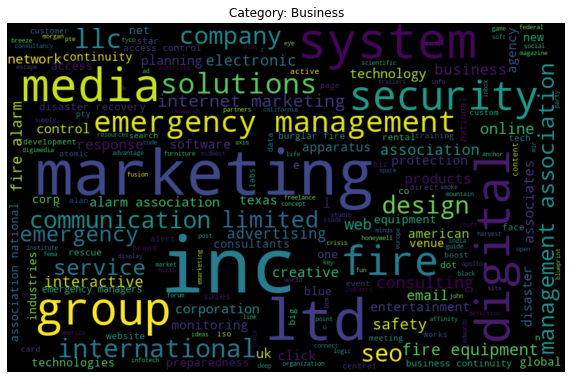

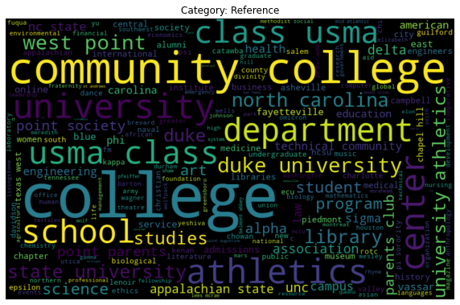

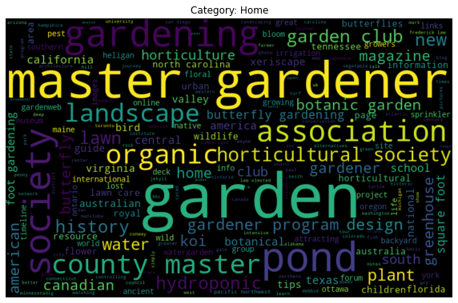

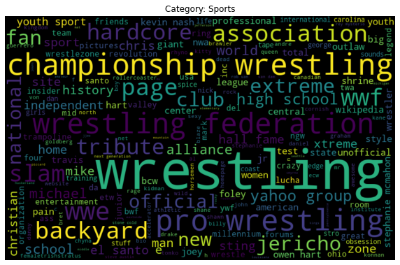

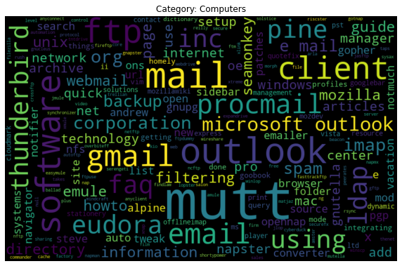

```python
for category in categories:
    all_words = ' '.join([text for text in websites[websites['category'] == category]['clean_title']])
    wordcloud = WordCloud(width=800, height=500, random_state=21, max_font_size=110).generate(all_words)

    plt.figure(figsize=(10, 7))
    plt.imshow(wordcloud, interpolation="bilinear")
    plt.title("Category: {}".format(category))
    plt.axis('off')
    plt.show()
```

We created a target_str column by combining category and url columns. Then we applied k-fold validation (k = 5). And we equated this to variable that name is cvlist.

```python
websites["target_str"] = websites["url"].astype(str) + '_' + websites["category"].astype(str)
cvlist = list(GroupKFold(5).split(websites, groups=websites["target_str"]))
```

```python
cvlist
```

```
[(array([    0,     1,     2, ..., 18883, 18885, 18887]),
  array([   13,    15,    17, ..., 18880, 18884, 18886])),
 (array([    1,     2,     3, ..., 18885, 18886, 18887]),
  array([    0,     4,     8, ..., 18868, 18879, 18883])),
 (array([    0,     1,     3, ..., 18883, 18884, 18886]),
  array([    2,     5,     6, ..., 18874, 18885, 18887])),
 (array([    0,     1,     2, ..., 18885, 18886, 18887]),
  array([    7,    10,    19, ..., 18876, 18878, 18882])),
 (array([    0,     2,     4, ..., 18885, 18886, 18887]),
  array([    1,     3,     9, ..., 18860, 18877, 18881]))]
```

We used the CountVectorizer object to convert the document to vectors.

```python
vec_bow = CountVectorizer(ngram_range=(1,4 ), min_df=400)
vec_bow.fit(websites['clean_title'])
Url_bow = vec_bow.transform(websites['clean_title'])
```

```python
websites.category.unique()
```

```
array(['Regional', 'Shopping', 'World', 'Arts', 'Society', 'Business',
       'Reference', 'Home', 'Sports', 'Computers'], dtype=object)
```

We converted the values (strings) belonging to the category column to numbers.

```python
X = Url_bow
Category_DICT = {"Regional":1, "Shopping": 2, "World":3, "Arts": 4,
            "Society": 5, "Business": 6, "Reference": 7,
            "Home": 8, "News": 9, "Sports": 10, "Computers": 11}

websites['target'] = websites.category.map(Category_DICT)
y = websites["target"].values
```

```python
websites
```

|  | id | url | title | description | category | cleaned_text | clean_title | target_str | target |
| --- | --- | --- | --- | --- | --- | --- | --- | --- | --- |
| 0 | 1 | http://www.firstworldwar.com/bio/lloydgeorge.htm | First World War.org - David Lloyd George | Short Biography from a site devoted to The Gre... | Regional | world david lloyd george | first world war org - david lloyd george | http://www.firstworldwar.com/bio/lloydgeorge.h... | 1 |
| 2 | 3 | http://www.infobritain.co.uk/David_Lloyd_Georg... | InfoBritain: David Lloyd George | Biographical article with a portrait. | Regional | infobritain david lloyd george | infobritain david lloyd george | http://www.infobritain.co.uk/David_Lloyd_Georg... | 1 |
| 3 | 4 | http://spartacus-educational.com/PRgeorge.htm | Lloyd George, David | Short biography by Spartacus Educational. | Regional | lloyd george david | lloyd george david | http://spartacus-educational.com/PRgeorge.htm_... | 1 |
| 7 | 8 | http://pubs.socialistreviewindex.org.uk/sr203/... | Socialist Review: The man who turned his back ... | Dave Renton describes the life of Ramsay MacDo... | Regional | socialist review man turn labour ramsay macdonald | socialist review man turned back labour - rams... | http://pubs.socialistreviewindex.org.uk/sr203/... | 1 |
| 8 | 9 | http://www.infobritain.co.uk/James_Ramsay_Macd... | InfoBritain: James Ramsay Macdonald | Biographical article. | Regional | infobritain james ramsay macdonald | infobritain james ramsay macdonald | http://www.infobritain.co.uk/James_Ramsay_Macd... | 1 |
| ... | ... | ... | ... | ... | ... | ... | ... | ... | ... |
| 19495 | 19496 | http://needlesearch.mozdev.org/ | NeedleSearch | Lets you bookmark search engines for future us... | Computers | needlesearch | needlesearch | http://needlesearch.mozdev.org/_Computers | 11 |
| 19496 | 19497 | http://nextimage.mozdev.org/ | mozdev.org - nextimage: index | An extension for Mozilla that can detect an im... | Computers | nextimage index | mozdev org - nextimage index | http://nextimage.mozdev.org/_Computers | 11 |
| 19497 | 19498 | http://pubmed.mozdev.org/ | PubMed | Allows you to search for information in NLM Me... | Computers | pubmed | pubmed | http://pubmed.mozdev.org/_Computers | 11 |
| 19498 | 19499 | http://slashzilla.mozdev.org/ | Slashzilla | A sidebar panel that provides the user with an... | Computers | slashzilla | slashzilla | http://slashzilla.mozdev.org/_Computers | 11 |
| 19499 | 19500 | http://stormzilla.mozdev.org/ | StormZilla | An extension to view your weather report via y... | Computers | stormzilla | stormzilla | http://stormzilla.mozdev.org/_Computers | 11 |

18888 rows × 9 columns

## Cross Validation

We wrote a function named cv_score that we can validate k-fold. For fitting on the training set for each fold, we set the model to be defined as a function input, because we want to try it on different models and both compare and increase the accuracy of the results.At the end of the function we calculated scores for each fold and printed and saved.

```python
def cv_score(ml_model, df):
    i = 1
    cv_scores = []
    X = df

    # Custom Cross validation based on group KFold
    for df_index,test_index in cvlist:
        print('\n{} of Group kfold {}'.format(i,5))
        xtr,xvl = X[df_index],X[test_index]
        ytr,yvl = y[df_index],y[test_index]

        # Define model for fitting on the training set for each fold
        model = ml_model
        model.fit(xtr, ytr)
        pred_probs = model.predict_proba(xvl)
        label_preds = np.argmax(pred_probs, axis=1) + 1

        # Calculate scores for each fold and print
        score = f1_score(yvl, label_preds, average="weighted")
        sufix = ""
        msg = ""
        msg += "Weighted F1 Score: {}".format(score)
        print("{}".format(msg))

         # Save scores
        cv_scores.append(score)
        i+=1
    return cv_scores
```

#### 1) Multinomial Naive Bayes Classifier Model

```python
cv_score(MultinomialNB(alpha=.01), Url_bow)
```

```
1 of Group kfold 5
Weighted F1 Score: 0.27595819733209986

2 of Group kfold 5
Weighted F1 Score: 0.2837356812369353

3 of Group kfold 5
Weighted F1 Score: 0.2655192982059185

4 of Group kfold 5
Weighted F1 Score: 0.27221856239915754

5 of Group kfold 5
Weighted F1 Score: 0.2889021581358909
```

```
[0.27595819733209986,
 0.2837356812369353,
 0.2655192982059185,
 0.27221856239915754,
 0.2889021581358909]
```

We used the Tfidf Vectorizer object to convert the document to vectors.

```python
# Word and character TFIDF on URLs
vec1 = TfidfVectorizer(analyzer='char', ngram_range=(1, 5), min_df=500)
vec2 = TfidfVectorizer(analyzer='word', ngram_range=(1, 3), min_df=400)
vec_tfidf = FeatureUnion([("char", vec1), ("word", vec2)])
vec_tfidf.fit(websites['clean_title'])
Url_tfidf = vec_tfidf.transform(websites['clean_title'])
```

```python
nb = cv_score(MultinomialNB(alpha=.01), Url_tfidf)
```

```
1 of Group kfold 5
Weighted F1 Score: 0.5655823134372971

2 of Group kfold 5
Weighted F1 Score: 0.5694419537152978

3 of Group kfold 5
Weighted F1 Score: 0.54795010761195

4 of Group kfold 5
Weighted F1 Score: 0.5519080415797613

5 of Group kfold 5
Weighted F1 Score: 0.5714232887921907
```

#### 2) Logistic Regression Model

```python
log_reg = cv_score(LogisticRegression(C=0.1,class_weight="balanced"), Url_tfidf)
```

```
1 of Group kfold 5
Weighted F1 Score: 0.5372893622559972

2 of Group kfold 5
Weighted F1 Score: 0.5444902345732261

3 of Group kfold 5
Weighted F1 Score: 0.5340021298979497

4 of Group kfold 5
Weighted F1 Score: 0.5471627664916013

5 of Group kfold 5
Weighted F1 Score: 0.5303163480493176
```

#### 3)Desicion Tree Classifier Model

```python
dtree = cv_score(DecisionTreeClassifier(min_samples_leaf=25, min_samples_split=25), Url_tfidf)
```

```
1 of Group kfold 5
Weighted F1 Score: 0.5817377102025361

2 of Group kfold 5
Weighted F1 Score: 0.5786399841702511

3 of Group kfold 5
Weighted F1 Score: 0.5653778095201486

4 of Group kfold 5
Weighted F1 Score: 0.575184174355313

5 of Group kfold 5
Weighted F1 Score: 0.5882397776382994
```

#### 4)Random Forest Classifier Model

```python
rf_params = {'random_state': 0, 'n_jobs': -1, 'n_estimators': 100, 'max_depth': 50, 'n_jobs': -1}
rf = cv_score(RandomForestClassifier(**rf_params), Url_tfidf)
```

```
1 of Group kfold 5
Weighted F1 Score: 0.6649354121982299

2 of Group kfold 5
Weighted F1 Score: 0.6648959287124898

3 of Group kfold 5
Weighted F1 Score: 0.6467341133824676

4 of Group kfold 5
Weighted F1 Score: 0.6486750917635166

5 of Group kfold 5
Weighted F1 Score: 0.6616283428128372
```

We created and visualized a dataframe to compare the results we got for each model.

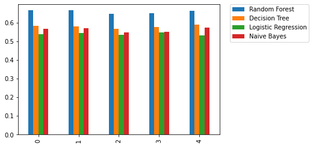

```python
#comparing results
results_df = pd.DataFrame({'Random Forest':rf, 'Decision Tree': dtree, 'Logistic Regression': log_reg, 'Naive Bayes':nb})
results_df.plot(y=["Random Forest", "Decision Tree","Logistic Regression","Naive Bayes"], kind="bar")
plt.legend(bbox_to_anchor=(1.05, 1), loc=2, borderaxespad=0.)
plt.show()
```